# R Notebook

# Quiz 1

## Setup

```r
install.packages(c("devtools"))
if (!requireNamespace("BiocManager", quietly = TRUE))
    install.packages("BiocManager")


BiocManager::install("Biobase")
BiocManager::install("GenomicRanges")
BiocManager::install("SummarizedExperiment")
```

```r
library(SummarizedExperiment)
library(Biobase)
library(GenomicRanges)
```

#### Testing the cache

```r
knitr::opts_chunk$set(cache=FALSE)
```

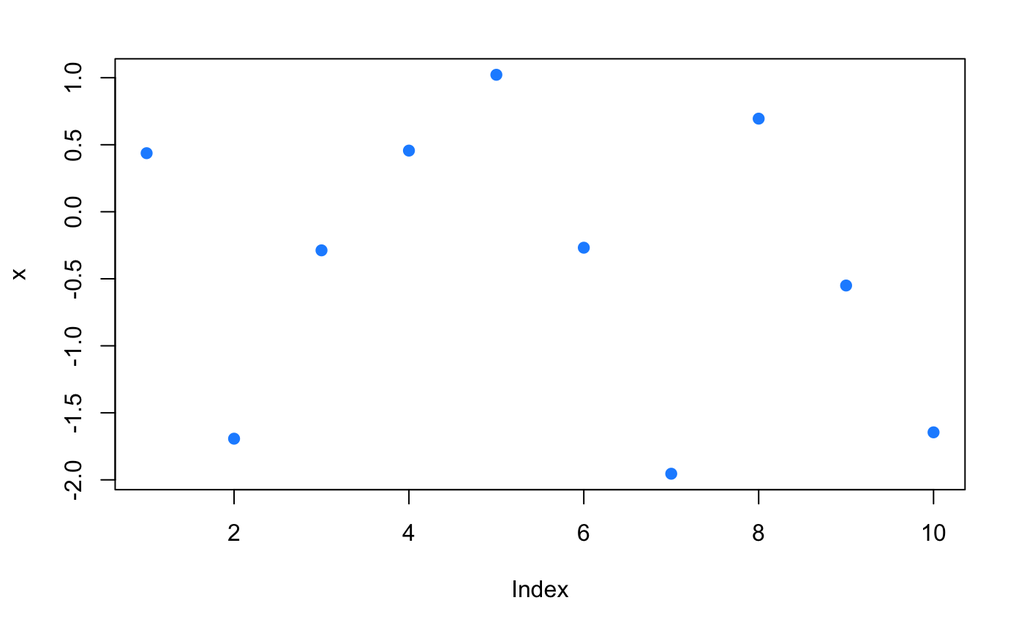

```r
x = rnorm(10)
plot(x,pch=19,col="dodgerblue")
```

```r
y = rbinom(20,size=1,prob=0.5)
table(y)
```

#### Working with SummarizedExperiment obj

```r
library(Biobase)
library(GenomicRanges)
data(sample.ExpressionSet, package = "Biobase")
se = makeSummarizedExperimentFromExpressionSet(sample.ExpressionSet)
```

```r
# genes (rows) x samples (columns).  Cells are expression values (normalized?)
assay(se)
```

```r
# phenotype data
colData(se)
```

```r
# shows the name of the genes that are being expressed. No data.  Returns a data fram
rowData(se)
```

```r
rowRanges(se)
```

### Experimental Design - Bottomly and Bodymap

```r
con =url("http://bowtie-bio.sourceforge.net/recount/ExpressionSets/bottomly_eset.RData")
load(file=con)
close(con)
bot = bottomly.eset
pdata_bot=pData(bot)

con =url("http://bowtie-bio.sourceforge.net/recount/ExpressionSets/bodymap_eset.RData")
load(file=con)
close(con)
bm = bodymap.eset
pdata_bm=pData(bm)
```

### Graphing Bodymap

```r
library(plotrix)
pie3D(pdata_bm$num.tech.reps,labels=pdata_bm$tissue.type)
```

### Bodymap Heatmaps

Which of the following code chunks will make a heatmap of the 500 most highly expressed genes (as defined by total count), without re-ordering due to clustering?

```r
edata = exprs(bm)
row_sums = rowSums(edata)
edata = edata[order(-row_sums),] #this reorders the rows
index = 1:500
heatmap(edata[index,],Rowv=NA,Colv=NA)
```

```r
edata = exprs(bm)
row_sums = rowSums(edata)
index = which(rank(row_sums) < 500 ) #no row_sums are less than 500.
#dim(index)
heatmap(edata[index,],Colv=NA)
```

```r
edata = exprs(bm)
row_sums = rowSums(edata)
edata = edata[order(row_sums),] #reorder rows. Ascending order.
index = which(rank(-row_sums) < 500)
heatmap(edata[index,],Rowv=NA, Colv=NA) #not sure why this failed.
```

```r
edata = exprs(bm)
row_sums = rowSums(edata)
index = which(rank(-row_sums) < 500 ) #rank has nothing to do with "rank" in linear algebra. It give you the indexes of the matrix in ascending order.
heatmap(edata[index,],Rowv=NA,Colv=NA)
```

### Bodymap graphs

Make an MA-plot of the first sample versus the second sample using the **log2** transform (hint: you may have to add 1 first) and the **rlog** transform from the DESeq2 package. How are the two MA-plots different? Which kind of genes appear most different in each plot?

```r
con =url("http://bowtie-bio.sourceforge.net/recount/ExpressionSets/bodymap_eset.RData")
load(file=con)
close(con)
bm = bodymap.eset
pdata = pData(bm)
edata = exprs(bm)
fdata = fData(bm)

#Now make the graph.
#sample1 vs. #sample2 with log2 transform.
par(pch=19)
```

#### MA-plots

https://en.wikipedia.org/wiki/MA_plot

```r
edata = exprs(bm)

sample1 = edata[,1]
sample2 = edata[,2]

sdiff = log2(sample1 + 1) - log2(sample2 + 1)
ssum  = log2(sample1 + 1) + log2(sample2 + 1)

plot(ssum, sdiff, col=2, xlab="A", ylab="M")
title("MA Plot")
```

### DESeq2 - rlog

- https://www.bioconductor.org/help/course-materials/2015/LearnBioconductorFeb2015/B02.1.1_RNASeqLab.html

```r
BiocManager::install("DESeq2")
```

```r
library(DESeq2)
```

```r
# https://www.bioconductor.org/help/course-materials/2015/LearnBioconductorFeb2015/B02.1.1_RNASeqLab.html
#This produces -Inf for zero values but might work.
#de_edata = rlog(data.matrix(edata))

#we could just add one to all cells.
de_edata = rlog(data.matrix(edata+1))

sde1 = de_edata[,1]
sde2 = de_edata[,2]

ssum  = sde1 + sde2
sdiff = sde1 - sde2

plot(ssum, sdiff, col=2, xlab="A", ylab="M")
title("MA Plot")
```

Todo:

- convert edata to a matrix?
  - data.matrix
  - DESeqDataSetFromMatrix
  - consider watching data exploration videos again.
- make another MA plot

Did both of the first two samples have the same phenotye / labels? Nope.

```r
colnames(pdata)
ps1 = pdata[1,]
ps2 = pdata[2,]
ps1$tissue.type
ps2$tissue.type
```

### Cluster the Data

```r
con =url("http://bowtie-bio.sourceforge.net/recount/ExpressionSets/montpick_eset.RData")
load(file=con)
close(con)
mp = montpick.eset
pdata=pData(mp)
edata=as.data.frame(exprs(mp))
fdata = fData(mp)
```

```r
install.packages('dendextend')
install.packages("rafalib")
```

```r
  library(dendextend)
  library(rafalib)
```

```r
dim(pdata) # sample x pheno type
```

```
[1] 129   4
```

```r
dim(edata)  # gene x sample
```

```
[1] 52580   129
```

```r
dim(fdata) #gene
```

```
[1] 52580     1
```

```r
colnames((pdata)) #pdata has the study.
```

```
[1] "sample.id"     "num.tech.reps" "population"    "study"
```

```r
unique(pdata$study) #only two different values.
```

```
[1] Montgomery Pickrell
Levels: Montgomery Pickrell
```

```r
pdata$study[0:10]
```

```
 [1] Montgomery Montgomery Montgomery Montgomery Montgomery Montgomery Montgomery Montgomery Montgomery
[10] Montgomery
Levels: Montgomery Pickrell
```

```r
tail(pdata$study, 10)
```

```
 [1] Pickrell Pickrell Pickrell Pickrell Pickrell Pickrell Pickrell Pickrell Pickrell Pickrell
Levels: Montgomery Pickrell
```

```r
is.data.frame(fdata)
```

```
[1] TRUE
```

```r
fdata$gene[1] #confuses me.
```

```
[1] ENSG00000000003
52580 Levels: ENSG00000000003 ENSG00000000005 ENSG00000000419 ENSG00000000457 ... LRG_99
```

#### Dendograms

```r
edata2 = edata[rowMeans(edata) >= 100,]
edata3 = log2(edata+1)
```

```r
dist1   = dist(t(edata))
hclust1 = hclust(dist1)
```

```r
ccolors = with(pdata, ifelse(study=='Montgomery', 1, 2))
myplclust(hclust1, labels = pdata$study, lab.col = ccolors, hang = 0.1, sub="Clustering - no Normalization")
```

```r
dist2   = dist(t(edata2))
hclust2 = hclust(dist2)
```

```r
ccolors = with(pdata, ifelse(study=='Montgomery', 1, 2))
myplclust(hclust2, labels = pdata$study, lab.col = ccolors, hang = 0.1, sub="Clustering - filter out rows with less raw counts")
```

```r
dist3   = dist(t(edata3))
hclust3 = hclust(dist3)
```

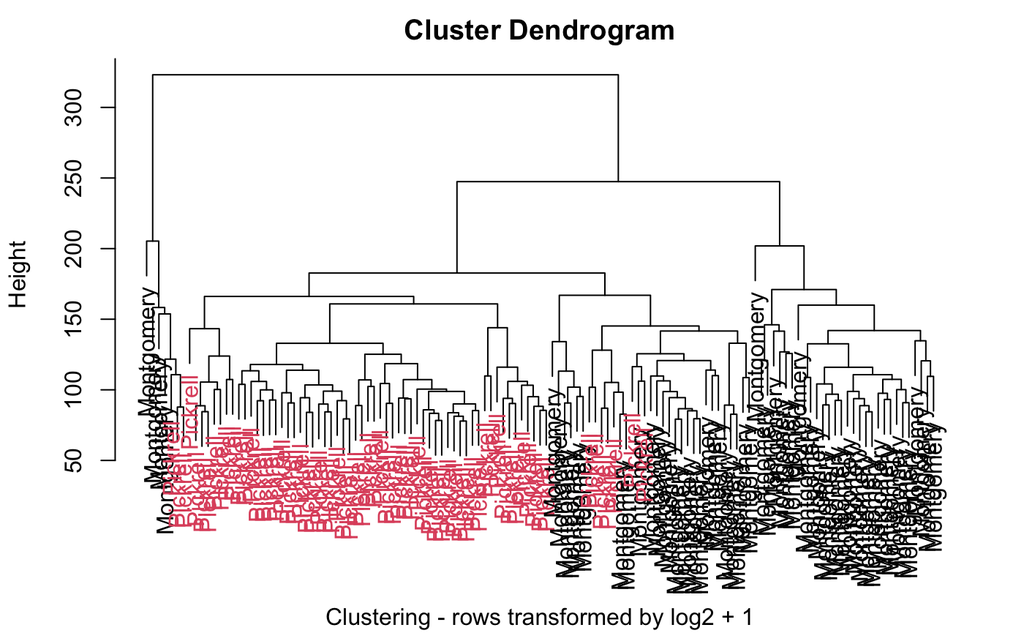

```r
ccolors = with(pdata, ifelse(study=='Montgomery', 1, 2))
myplclust(hclust3, labels = pdata$study, lab.col = ccolors, hang = 0.1, sub="Clustering - rows transformed by log2 + 1")
```

```r
cutree(hclust3, 2)
```

```
NA06985 NA06986 NA06994 NA07000 NA07037 NA07051 NA07346 NA07347 NA07357 NA10847 NA10851 NA11829 NA11830
      1       1       1       1       1       1       1       1       1       1       1       1       1
NA11831 NA11832 NA11840 NA11881 NA11894 NA11918 NA11920 NA11931 NA11992 NA11993 NA11994 NA11995 NA12003
      1       1       1       1       1       2       1       1       1       1       1       1       1
NA12004 NA12005 NA12006 NA12043 NA12044 NA12045 NA12144 NA12154 NA12155 NA12156 NA12234 NA12249 NA12287
      2       1       1       1       1       1       1       1       1       1       1       1       1
NA12414 NA12489 NA12716 NA12717 NA12750 NA12751 NA12760 NA12761 NA12762 NA12763 NA12776 NA12812 NA12813
      1       1       1       2       1       1       1       1       1       1       1       1       1
NA12814 NA12815 NA12828 NA12872 NA12873 NA12874 NA12891 NA12892 NA18486 NA18498 NA18499 NA18501 NA18502
      1       1       1       1       1       1       1       2       1       1       1       1       1
NA18504 NA18505 NA18507 NA18508 NA18510 NA18511 NA18516 NA18517 NA18519 NA18520 NA18522 NA18523 NA18852
      1       1       1       1       1       1       1       1       1       1       1       1       1
NA18853 NA18855 NA18856 NA18858 NA18861 NA18862 NA18870 NA18871 NA18909 NA18912 NA18913 NA18916 NA19093
      1       1       1       1       1       1       1       1       1       2       1       1       1
NA19098 NA19099 NA19101 NA19102 NA19108 NA19114 NA19116 NA19119 NA19127 NA19128 NA19130 NA19131 NA19137
      1       1       1       2       1       1       1       2       1       1       1       1       1
NA19138 NA19140 NA19143 NA19144 NA19147 NA19152 NA19153 NA19159 NA19160 NA19171 NA19172 NA19190 NA19192
      1       1       1       1       1       1       1       1       1       1       1       1       1
NA19193 NA19200 NA19201 NA19203 NA19204 NA19209 NA19210 NA19222 NA19225 NA19238 NA19239 NA19257
      1       1       1       1       1       1       1       1       1       1       1       1
```

#### K-means Clustering

```r
con =url("http://bowtie-bio.sourceforge.net/recount/ExpressionSets/montpick_eset.RData")
load(file=con)
close(con)
mp = montpick.eset
pdata=pData(mp)
edata=as.data.frame(exprs(mp))
fdata = fData(mp)
```

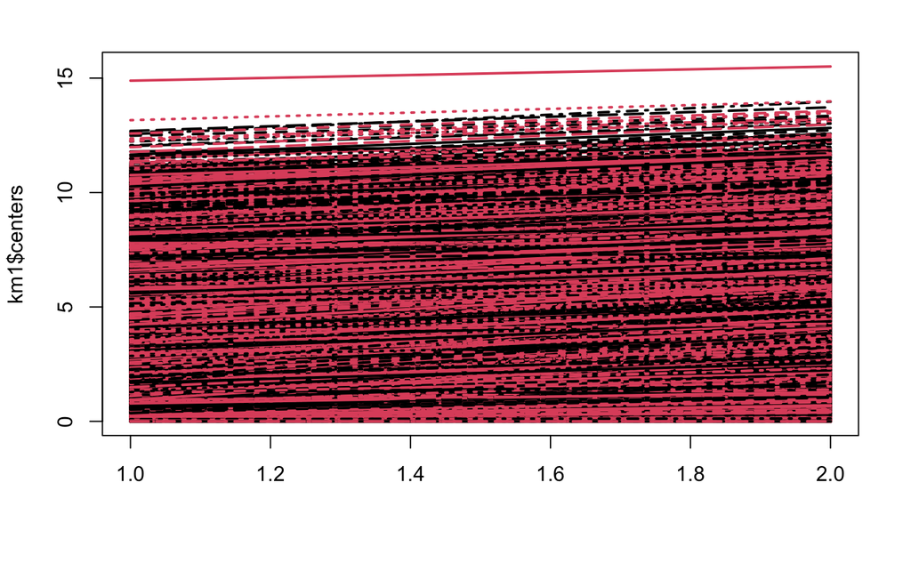

```r
set.seed(1235)
edl = log2(edata+1)
km1 = kmeans(t(edl), centers=2) #I think I need columns to be clustered (not rows)
matplot(km1$centers, col=1:2, type="l", lwd=2) #I guess you graph every dim of each km.
```

```r
km1$cluster
```

```
NA06985 NA06986 NA06994 NA07000 NA07037 NA07051 NA07346 NA07347 NA07357 NA10847 NA10851 NA11829 NA11830
      1       1       1       1       1       1       1       1       1       1       1       1       1
NA11831 NA11832 NA11840 NA11881 NA11894 NA11918 NA11920 NA11931 NA11992 NA11993 NA11994 NA11995 NA12003
      1       2       2       1       1       1       1       2       2       1       1       1       1
NA12004 NA12005 NA12006 NA12043 NA12044 NA12045 NA12144 NA12154 NA12155 NA12156 NA12234 NA12249 NA12287
      1       1       1       2       2       2       1       2       1       1       1       1       1
NA12414 NA12489 NA12716 NA12717 NA12750 NA12751 NA12760 NA12761 NA12762 NA12763 NA12776 NA12812 NA12813
      1       1       1       1       1       1       2       1       1       1       2       2       1
NA12814 NA12815 NA12828 NA12872 NA12873 NA12874 NA12891 NA12892 NA18486 NA18498 NA18499 NA18501 NA18502
      2       1       1       2       1       2       1       1       2       2       2       2       2
NA18504 NA18505 NA18507 NA18508 NA18510 NA18511 NA18516 NA18517 NA18519 NA18520 NA18522 NA18523 NA18852
      2       2       2       2       2       2       2       2       2       2       2       2       2
NA18853 NA18855 NA18856 NA18858 NA18861 NA18862 NA18870 NA18871 NA18909 NA18912 NA18913 NA18916 NA19093
      2       2       1       2       2       2       2       2       2       1       2       2       2
NA19098 NA19099 NA19101 NA19102 NA19108 NA19114 NA19116 NA19119 NA19127 NA19128 NA19130 NA19131 NA19137
      2       2       2       1       2       2       2       1       2       2       2       2       2
NA19138 NA19140 NA19143 NA19144 NA19147 NA19152 NA19153 NA19159 NA19160 NA19171 NA19172 NA19190 NA19192
      2       2       2       2       2       2       2       2       2       1       2       2       2
NA19193 NA19200 NA19201 NA19203 NA19204 NA19209 NA19210 NA19222 NA19225 NA19238 NA19239 NA19257
      2       1       2       2       2       2       2       2       2       2       2       2
```

```r
table(km1$cluster)
```

```
 1  2
52 77
```

```r
#how right was kmeans?
ground_truth = with(pdata, ifelse(study=='Montgomery', 1, 2))
```

```r
colramp = colorRampPalette(c(3,"white",2))(9)
#this just shows the cluster (not the study)
heatmap(as.matrix(edl)[order(km1$cluster),], col=colramp, Colv=NA, Rowv=NA)
```

### Bonus exploratory data analysis

```r
table(pdata$gender, pdata$tissue.type) #super sparse.
table(pdata$gender, pdata$race)

summary(edata)
```

Three tables of genomic data science

- expression data
- data about patient / sample phenotypes
- data about each gene (pathways, snps?, etc.)

In R the common classes that allow you to work with the three tables

- ExpressionSet
  - assayData
  - phenoData
  - featureData

```r
#assume you retrieved bm and bot datasets
# these classes use ExpressionSet and AnnotatedDataFrame
f_bm = featureData(bm)[0:10,]
varMetadata(f_bm)
featureNames(f_bm)
```

- SummarizedExperiment
  - assays
  - colData
  - rowData

```r
#assume you loaded se
# SummarizedExperiment
fd_se = rowData(se)[0:10,]
dim(fd_se) #500 x 0 - no data
```

```
[1] 10  0
```

```r
rownames(fd_se)
```

```
 [1] "AFFX-MurIL2_at"  "AFFX-MurIL10_at" "AFFX-MurIL4_at"  "AFFX-MurFAS_at"  "AFFX-BioB-5_at"
 [6] "AFFX-BioB-M_at"  "AFFX-BioB-3_at"  "AFFX-BioC-5_at"  "AFFX-BioC-3_at"  "AFFX-BioDn-5_at"
```

## Session information

It is also useful to compile the time the document was processed. This document was processed on: 2020-05-19.